# Clase 1: Ejercicios — Solución

30 de junio de 2026

# Parte 1 — R básico

**Ejercicio 1.** Calcula lo siguiente:

```r
# a) Raíz cuadrada de 225 más 3 elevado a la 4
#    sqrt(225) = 15,  3^4 = 81,  15 + 81 = 96
sqrt(225) + 3^4
```

```
## [1] 96
```

```r
# b) Residuo de dividir 1000 entre 7 (operador %%)
#    1000 = 142*7 + 6  -> residuo = 6
1000 %% 7
```

```
## [1] 6
```

```r
# c) e elevado a la 2
#    exp(2) ≈ 7.389056
exp(2)
```

```
## [1] 7.389056
```

**Ejercicio 2.** México tuvo en 2023 un PIB nominal de 29,700 miles de millones de pesos y un deflactor del PIB de 148.3 (base 2013 = 100). Guarda cada valor en un objeto con nombre descriptivo y calcula el PIB real. Datos: PIB nominal 29,700 miles de millones, deflactor 148.3 (base 2013 = 100). PIB real = PIB nominal / (deflactor/100).

```r
pib_nominal   <- 29700  # miles de millones de pesos
deflactor_pib <- 148.3          # base 2013 = 100
pib_real      <- pib_nominal / (deflactor_pib / 100)
pib_real
```

```
## [1] 20026.97
```

```r
# Interpretación: el PIB real (a precios de 2013) es aprox. 20,027
# miles de millones de pesos. La diferencia con el nominal es la inflación
# acumulada desde 2013.
```

**Ejercicio 3.** Sin correr el código, escribe en un comentario si cada expresión devuelve `TRUE` o `FALSE`. Luego verifica: Predicciones:

```r
# 10 == 10         -> TRUE   (igualdad numérica)
# 10 != 10         -> FALSE  (sí son iguales, así que "no distintos" es FALSE)
# (5 > 3) & (8 < 5)-> FALSE  (TRUE & FALSE -> FALSE)
# (5 > 3) | (8 < 5)-> TRUE   (TRUE | FALSE -> TRUE; basta con que una sea TRUE)
# !(3 > 1)         -> FALSE  (3>1 es TRUE, su negación es FALSE)

10 == 10
```

```
## [1] TRUE
```

```r
10 != 10
```

```
## [1] FALSE
```

```r
(5 > 3) & (8 < 5)
```

```
## [1] FALSE
```

```r
(5 > 3) | (8 < 5)
```

```
## [1] TRUE
```

```r
!(3 > 1)
```

```
## [1] FALSE
```

# Parte 2 — Tipos de datos y vectores

**Ejercicio 4.** Para cada objeto, escribe en un comentario qué tipo crees que es *antes* de verificarlo con `class()`. Al final explica por qué `d` no es numérico aunque parece serlo:

```r
a <- 19500.75
b <- "tasa de desempleo"
c <- FALSE
d <- "2.8"

# Predicción:
# a -> numeric (número con decimales)
# b -> character (está entre comillas)
# c -> logical (TRUE/FALSE)
# d -> character  ←  Parece número pero las comillas lo vuelven texto.

class(a)
```

```
## [1] "numeric"
```

```r
class(b)
```

```
## [1] "character"
```

```r
class(c)
```

```
## [1] "logical"
```

```r
class(d)
```

```
## [1] "character"
```

```r
#
# "d" no es numérico porque cualquier valor entre comillas dobles "" o simples '' se interpreta
# como cadena de texto (character).
```

**Ejercicio 5.** Tenemos datos de desempleo para 20 países de América Latina y el Caribe. Usa los datos generados para contestar las preguntas.

```r
set.seed(42)
paises <- c("México", "Brasil", "Argentina", "Colombia", "Chile", "Perú",
            "Venezuela", "Ecuador", "Bolivia", "Paraguay", "Uruguay",
            "Costa Rica", "Panamá", "Guatemala", "Honduras", "El Salvador",
            "Nicaragua", "Cuba", "República Dominicana", "Jamaica")

desempleo <- round(runif(n = 20, min = 2.0, max = 15.0), 1)

# a) Tasa promedio
mean(desempleo)
```

```
## [1] 9.97
```

```r
# b) ¿Cuántos países están por encima del promedio?

sum(desempleo > mean(desempleo))
```

```
## [1] 11
```

```r
# c) Países con desempleo menor a 7%
paises[desempleo < 7]
```

```
## [1] "Argentina" "Ecuador"   "Guatemala" "Cuba"
```

```r
# d) Vector lógico: TRUE para desempleo > 10%
alto_desempleo <- desempleo > 10
alto_desempleo
```

```
##  [1]  TRUE  TRUE FALSE  TRUE  TRUE FALSE  TRUE FALSE  TRUE  TRUE FALSE  TRUE
## [13]  TRUE FALSE FALSE  TRUE  TRUE FALSE FALSE FALSE
```

# Parte 3 — Data frames

**Ejercicio 6.** Panel de 30 países.

```r
set.seed(7)
n <- 30

paises_macro <- c("México", "Brasil", "Argentina", "Colombia", "Chile", "Perú",
                  "Venezuela", "Ecuador", "Bolivia", "Paraguay", "Uruguay",
                  "Costa Rica", "Panamá", "Guatemala", "Honduras", "El Salvador",
                  "Nicaragua", "Cuba", "Rep. Dominicana", "Jamaica",
                  "Trinidad y Tobago", "Bahamas", "Haití", "Belice", "Guyana",
                  "Surinam", "Barbados", "Santa Lucía", "Granada", "Dominica")

macro <- data.frame(
  pais      = paises_macro,
  pib       = round(runif(n, min = 50,   max = 2500), 1),  # miles de mill. USD
  inflacion = round(runif(n, min = 1.5,  max = 50.0), 1),  # %
  desempleo = round(runif(n, min = 2.0,  max = 18.0), 1)   # %
)

# a) Resumen estadístico
summary(macro)
```

```
##      pais                pib           inflacion       desempleo
##  Length:30          Min.   :  71.3   Min.   : 5.50   Min.   : 3.30
##  Class :character   1st Qu.: 507.4   1st Qu.:17.73   1st Qu.: 7.75
##  Mode  :character   Median :1092.7   Median :27.50   Median : 9.90
##                     Mean   :1239.8   Mean   :27.88   Mean   :10.22
##                     3rd Qu.:1978.7   3rd Qu.:39.60   3rd Qu.:12.95
##                     Max.   :2491.9   Max.   :48.40   Max.   :16.90
```

```r
# b) Columna lógica: inflación > 10%
macro$inflacion_alta <- macro$inflacion > 10
head(macro, 5)
```

```
##        pais    pib inflacion desempleo inflacion_alta
## 1    México 2472.8      34.5       5.1           TRUE
## 2    Brasil 1024.5      14.3      10.1           TRUE
## 3 Argentina  333.5      10.5      14.2           TRUE
## 4  Colombia  220.9      10.5      13.1           TRUE
## 5     Chile  647.2      19.9      10.7           TRUE
```

```r
# c) Filtrar desempleo < 8%
desempleo_bajo <- macro[macro$desempleo < 8, ]
desempleo_bajo
```

```
##        pais    pib inflacion desempleo inflacion_alta
## 1    México 2472.8      34.5       5.1           TRUE
## 9   Bolivia  456.3      42.2       7.4           TRUE
## 11  Uruguay  470.8      40.3       6.6           TRUE
## 15 Honduras 1160.9      45.4       4.2           TRUE
## 23    Haití 2491.9      39.0       5.9           TRUE
## 26  Surinam  210.8      20.3       3.3           TRUE
## 27 Barbados 1586.2       9.4       3.5          FALSE
## 29  Granada 2429.0      20.5       7.6           TRUE
```

```r
# d) Países con inflación alta Y desempleo bajo, simultáneamente
sum(macro$inflacion > 10 & macro$desempleo < 8)
```

```
## [1] 7
```

# Parte 4 — Matrices (OLS)

El estimador de Mínimos Cuadrados Ordinarios tiene la siguiente forma matricial:

$$\hat{\beta} =
(X'X)^{-1}X'y$$

Donde $X$ es la matriz de regresores (con una columna de unos para la constante) e $y$ es el vector de la variable dependiente.

Ya tenemos los datos, el gráfico, y la matriz $X$ construida. Tu trabajo es calcular $\hat{\beta}$ paso a paso:

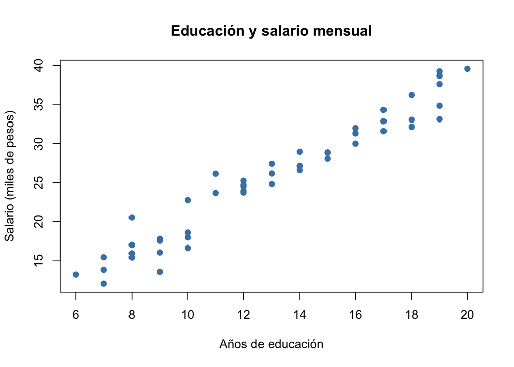

```r
set.seed(123)

n          <- 50
educacion  <- round(runif(n, min = 6, max = 20), 0)   # años de educación
error      <- rnorm(n, mean = 0, sd = 2)               # ruido aleatorio
salario    <- 2 + 1.8 * educacion + error              # miles de pesos al mes

# Gráfico ya hecho — obsérvalo antes de estimar
plot(educacion, salario,
     main = "Educación y salario mensual",
     xlab = "Años de educación",
     ylab = "Salario (miles de pesos)",
     pch  = 19, col = "steelblue")
```

```r
X <- matrix(c(rep(1, n), educacion), nrow = n, ncol = 2)
colnames(X) <- c("constante", "educacion")
y <- matrix(salario, nrow = n)
```

**a)** $X'X$ y su inversa $(X'X)^{-1}$

```r
# X'X: transpuesta de X por X.  Resultado 2x2.
XtX <- t(X) %*% X
XtX
```

```
##           constante educacion
## constante        50       662
## educacion       662      9588
```

```r
# Inversa: solve() resuelve sistemas lineales y, con un solo argumento,
# devuelve la inversa de la matriz.
XtX_inv <- solve(XtX)
XtX_inv
```

```
##             constante   educacion
## constante  0.23296725 -0.01608514
## educacion -0.01608514  0.00121489
```

**b)** $X'y$.

```r
Xty <- t(X) %*% y
Xty
```

```
##                [,1]
## constante  1297.219
## educacion 18702.212
```

**c)** $\hat{\beta} = (X'X)^{-1}X'y$.

```r
betas <- XtX_inv %*% Xty
betas
```

```
##               [,1]
## constante 1.381827
## educacion 1.855178
```

**d)** Verificación con `lm()` — debe dar lo mismo:

```r
coeficientes_lm <- coef(lm(salario ~ educacion))
coeficientes_lm
```

```
## (Intercept)   educacion
##    1.381827    1.855178
```

```r
# Comprobación
all.equal(unname(betas), unname(coeficientes_lm))
```

```
## [1] "Attributes: < Modes: list, NULL >"
## [2] "Attributes: < Lengths: 1, 0 >"
## [3] "Attributes: < names for target but not for current >"
## [4] "Attributes: < current is not list-like >"
## [5] "target is matrix, current is numeric"
```

# Parte 5 — Refactorización del código “2am”

El siguiente script fue escrito a las 2am antes de una presentación. Funciona. Pero nadie sabe qué hace.

Tu tarea es dos cosas:

1. Reescríbelo con nombres descriptivos y formato legible
2. Explica en un comentario qué hace cada línea

```r
set.seed(2026)
n <- 32
g <- c("Grupo A","Grupo B","Grupo C","Grupo D",
       "Grupo E","Grupo F",
       "Grupo G","Grupo H")
d <- data.frame(
  eq  = paste0("Selección_", 1:n),
  gf  = round(runif(n, 0, 15)),
  gc  = round(runif(n, 0, 15)),
  pos = round(runif(n, 1, 32)),
  grp = rep(g, each = 4)
)
d$dg  <- d$gf - d$gc
d$ef  <- ifelse(d$dg > 0, 1, 0)
d2    <- d[order(-d$gf), ]
d3    <- d2[1:8, ]
m     <- mean(d3$gf)
s     <- sd(d3$gf)
d3$z  <- (d3$gf - m) / s
cat("Promedio:", round(m, 2), "\n")
```

```
## Promedio: 10.75
```

```r
cat("Top equipo:", d3$eq[1], "con", d3$gf[1], "goles\n")
```

```
## Top equipo: Selección_31 con 14 goles
```

```r
## 2) Código reescrito con nombres descriptivos y comentarios
```

```r
set.seed(2026)

# --- 1. Configuración -------------------------------------------------------
n_equipos       <- 32
n_por_grupo     <- 4
n_grupos        <- n_equipos / n_por_grupo   # 8 grupos

nombres_grupos <- c("Grupo A", "Grupo B", "Grupo C", "Grupo D",
                    "Grupo E", "Grupo F", "Grupo G", "Grupo H")

# --- 2. Simulación de la base de datos -------------------------------------
equipos <- data.frame(
  nombre  = paste0("Selección_", 1:n_equipos),
  gf      = round(runif(n_equipos, 0, 15)),    # goles a favor
  gc      = round(runif(n_equipos, 0, 15)),    # goles en contra
  posicion = round(runif(n_equipos, 1, 32)),   # posición final en el torneo
  grupo   = rep(nombres_grupos, each = n_por_grupo)
)

# --- 3. Variables derivadas -------------------------------------------------
# Diferencia de goles: positiva = anota más de lo que recibe.
equipos$diferencia_goles  <- equipos$gf - equipos$gc

# ¿Ganó? 1 si la diferencia de goles es positiva, 0 en otro caso.
equipos$gano <- ifelse(equipos$diferencia_goles > 0, 1, 0)

# --- 4. Ranking: top 8 por goles a favor ------------------------------------
equipos_ordenados <- equipos[order(-equipos$gf), ]
top8              <- equipos_ordenados[1:8, ]

# --- 5. Estandarización (z-score) de los goles a favor del top 8 ------------
media_gf  <- mean(top8$gf)
desvio_gf <- sd(top8$gf)
top8$gf_z <- (top8$gf - media_gf) / desvio_gf

# --- 6. Reporte en consola --------------------------------------------------
cat("Promedio:", round(media_gf, 2), "\n")
```

```
## Promedio: 10.75
```

```r
cat("Top equipo:", top8$nombre[1], "con", top8$gf[1], "goles\n")
```

```
## Top equipo: Selección_31 con 14 goles
```